# Brain Cancer Survival Analysis

Alec Becker

2021-11-27

### Introduction

This analysis uses the `BrainCancer` dataset from the `ISLR2` R package to perform survival analysis. The outcome of interest is risk of death over time after receiving a brain cancer diagnosis.

*Note: The ISLR2 package is available on CRAN: https://CRAN.R-project.org/package=ISLR2*

### Set up and data import

First, we load the packages and data that will be used.

```r
# Load libraries
library(ISLR2)
library(tidyverse)
library(survival)
library(survminer)
library(missForest)

# Call and rename dataset from ISLR2 package
data(BrainCancer)
df <- BrainCancer
```

Next, we examine the structure of the data using the `str()` function and get a glimpse of the first few rows using the `head()` function.

```r
str(df)
```

```
## 'data.frame':    88 obs. of  8 variables:
##  $ sex      : Factor w/ 2 levels "Female","Male": 1 2 1 1 2 1 2 2 1 2 ...
##  $ diagnosis: Factor w/ 4 levels "Meningioma","LG glioma",..: 1 3 1 2 3 1 1 2 1 3 ...
##  $ loc      : Factor w/ 2 levels "Infratentorial",..: 1 2 1 2 2 2 2 2 2 2 ...
##  $ ki       : int  90 90 70 80 90 80 80 80 70 100 ...
##  $ gtv      : num  6.11 19.35 7.95 7.61 5.06 ...
##  $ stereo   : Factor w/ 2 levels "SRS","SRT": 1 2 1 2 2 1 2 2 2 2 ...
##  $ status   : int  0 1 0 1 1 0 0 0 0 0 ...
##  $ time     : num  57.64 8.98 26.46 47.8 6.3 ...
```

```r
head(df)
```

```
##      sex  diagnosis            loc ki   gtv stereo status  time
## 1 Female Meningioma Infratentorial 90  6.11    SRS      0 57.64
## 2   Male  HG glioma Supratentorial 90 19.35    SRT      1  8.98
## 3 Female Meningioma Infratentorial 70  7.95    SRS      0 26.46
## 4 Female  LG glioma Supratentorial 80  7.61    SRT      1 47.80
## 5   Male  HG glioma Supratentorial 90  5.06    SRT      1  6.30
## 6 Female Meningioma Supratentorial 80  4.82    SRS      0 52.75
```

From the `str()` output, we see the dataset contains 88 observations and 8 variables. The `head()` output helps us understand the data by showing the column names and some example rows.

### Data preparation

To check for missingness, we apply an anonymous function to obtain the total number of missing values in each column. `sapply()` handles applying the function to each column and returning the output in the simplest form possible – in this case, a vector.

```r
sapply(df, function(x) sum(is.na(x)))
```

```
##       sex diagnosis       loc        ki       gtv    stereo    status      time
##         0         1         0         0         0         0         0         0
```

We see the dataset’s only missing value is in the `diagnosis` variable. We would likely be safe dropping this observation and proceeding with the 87 complete rows. It is unlikely that excluding one observation would introduce much bias in the analysis.

However, we want to retain every observation possible because we are working with a small dataset. We want to maximize statistical power as well as the amount of data available to train and test a model. To keep this observation, we impute the missing value using a [random forest](https://link.springer.com/article/10.1007/s11749-016-0481-7) model. We use the `missForest` package to fit and evaluate a model, use that model to impute the missing value, then save the newly complete dataset in the `df_imputed` object.

```r
set.seed(1) # We set a random seed for reproducibility because there is randomness in the random forest algorithm
rf_imputation <- missForest::missForest(df)
```

```r
rf_imputation$OOBerror
```

```
##     NRMSE       PFC
## 0.0000000 0.1149425
```

```r
df_imputed <- rf_imputation$ximp
```

The `OOBerror` ([out-of-bag error](https://scikit-learn.org/stable/auto_examples/ensemble/plot_ensemble_oob.html)) of the model was a percent falsely classified (PFC) of about 11%. The reported normalized [root mean squared error](https://www.sciencedirect.com/topics/engineering/root-mean-squared-error) (NRMSE) is not relevant in our case because the only variable with missing values, `diagnosis`, was nominal. The PFC of 11% tells us the model was about 89% accurate at predicting nominal variables. Given this relatively high accuracy, we trust the imputation of the missing `diagnosis` value to most likely match the truth and proceed in the analysis as if it was the true value.

### Exploratory data analysis

We now examine the complete dataset’s summary statistics using the `summary()` function.

```r
# Variable summary statistics
summary(df_imputed)
```

```
##      sex          diagnosis              loc           ki
##  Female:45   Meningioma:43   Infratentorial:19   Min.   : 40.00
##  Male  :43   LG glioma : 9   Supratentorial:69   1st Qu.: 80.00
##              HG glioma :22                       Median : 80.00
##              Other     :14                       Mean   : 81.02
##                                                  3rd Qu.: 90.00
##                                                  Max.   :100.00
##       gtv         stereo       status            time
##  Min.   : 0.010   SRS:23   Min.   :0.0000   Min.   : 0.07
##  1st Qu.: 2.500   SRT:65   1st Qu.:0.0000   1st Qu.:10.39
##  Median : 6.510            Median :0.0000   Median :24.03
##  Mean   : 8.661            Mean   :0.3977   Mean   :27.46
##  3rd Qu.:12.100            3rd Qu.:1.0000   3rd Qu.:41.60
##  Max.   :34.640            Max.   :1.0000   Max.   :82.56
```

The ouput show us that:

- The modal `sex` (binary biological sex of the observation) was female (45/88, or 51%).
- The modal `diagnosis` (type of brain cancer diagnosis received) was [meningioma](https://braintumor.org/brain-tumor-information/brain-tumor-glossary/?gclid=Cj0KCQiAhf2MBhDNARIsAKXU5GQaT6n9tusZiDQszt64wEeQ2oPlOVWVK6-QLsSn9-8aKaR8jCB3WOUaAhHlEALw_wcB) (43/88, or 49%).
- The modal `loc` (location of the tumor within the brain) was [supratentorial](https://www.ncbi.nlm.nih.gov/books/NBK65903/figure/CDR0000574573__205/) (69/88, or 78%).
- The mean and median of `ki` ([Karnofsky index](https://www.sciencedirect.com/topics/medicine-and-dentistry/karnofsky-performance-status)) was about 81 and 80, respectively. The closeness of the mean and median suggests the distribution is likely symmetric.
- The mean and median of `gtv` (gross tumor volume, in cubic centimeters) was about 9 and 7, respectively. The larger mean in comparison with the median suggests the distribution may have right skew.
- The modal `stereo` (type of stereotactic radiation received) was SRT (65/88, or 74%).
- As shown by the mean of `status` (binary indicator for patient death by end of study period), about 40% of the observations were known to have died during the study period. The remaining 60% were **censored**, meaning they either dropped out before the study period ended and could no longer be observed or were known to be alive at the end of the study period.
- The mean and median of `time` (survival/observation time) was about 27 and 24 months, respectively. There may be slight right skew in this variable’s distribution.

To explore how survival probability changed over time, we fit and plot a Kaplan-Meier curve using the `survival` and `survminer` packages. This method accounts for the censoring present in the data (indicated by `status` = 0). Censored observations require special handling because their survival time is unknown.

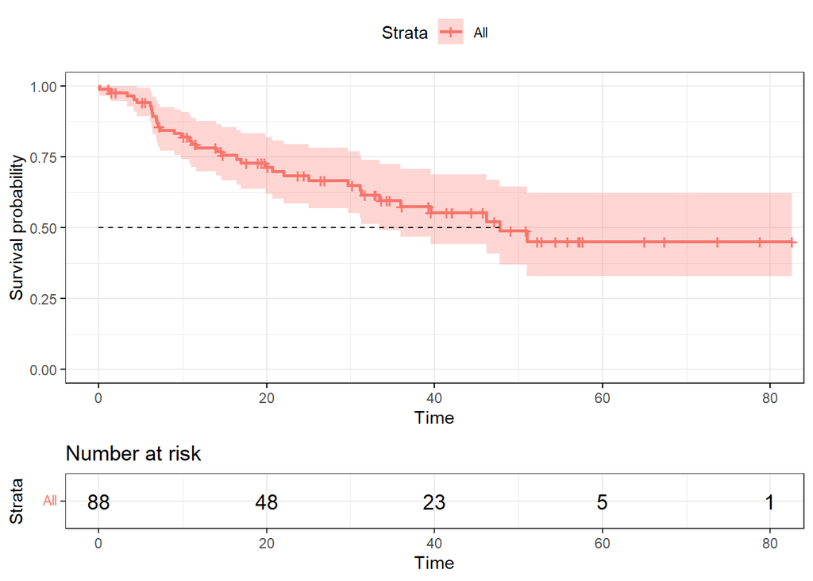

```r
# Fit and plot a Kaplan-Meier curve for the full training sample
surv_fit1 <- survival::survfit(survival::Surv(time, status) ~ 1, data = df_imputed)
survminer::ggsurvplot(surv_fit1, data = df_imputed, surv.median.line = "h", risk.table = TRUE, ggtheme = theme_bw())
```

The above plot shows the sample’s median survival time, or the time point at which survival probability reached 50%, was a bit under 50 months post-diagnosis. From there, survival probability marginally decreased and then plateaued at longer durations.

While informative, we really want to understand how the explanatory variables may have impacted survival probability. To do that, we fit a Kaplan-Meier curve for each of the categorical predictors (i.e., `sex`, `diagnosis`, `loc`, and `stereo`.) We fit plots for the continuous variables in a later step.

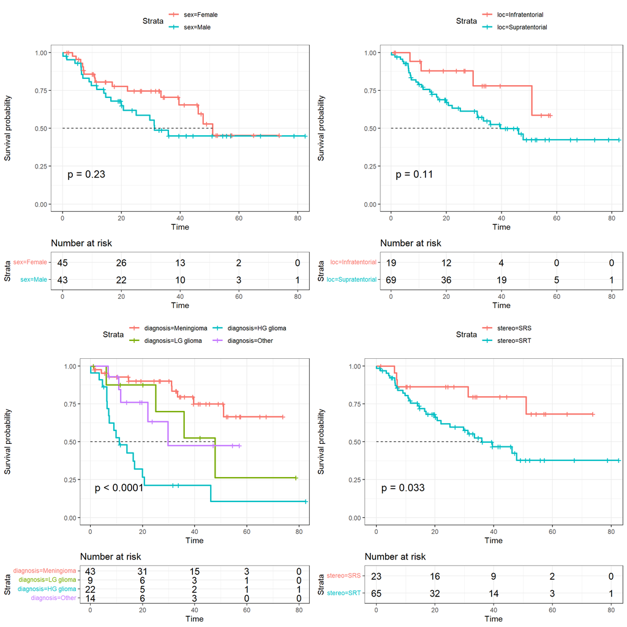

```r
# Define a vector of the factor variables in the dataset
cat_vars <- c("sex", "diagnosis", "loc", "stereo")

# Create a list of Kaplan-Meier plots for each factor variable
surv_plots <- lapply(cat_vars, function(x) {
  formula <- as.formula(paste0("survival::Surv(time, status) ~ ", x))
  surv_fit <- survminer::surv_fit(formula, data = df_imputed)
  survplot <- ggsurvplot(surv_fit, data = df_imputed, pval = TRUE, surv.median.line = "h", risk.table = TRUE, ggtheme = theme_bw()) +
               guides(color = guide_legend(nrow = 2))
})

# Arrange the Kaplan-Meier plots on a 2 x 2 grid
survminer::arrange_ggsurvplots(surv_plots, ncol = 2, nrow = 2)
```

From the plots above, we see that `diagnosis` (type of brain cancer diagnosis) and `stereo` (type of stereotactic radiation received) had statistically significant relationships with survival at the 95% confidence level. Among the types of diagnoses in this dataset, high-grade (HG) glioma appeared to be the most lethal. Of the two stereotactic radiation types, receiving SRT (i.e., stereotactic radiotherapy) was related to lower probability of survival over time.

Based on visual inspection, `sex` and `loc` (location of brain cancer) may have been related to survival. However, the p-values for both were greater than 0.05. This means we cannot reject the null hypothesis and we cannot say with at least 95% confidence that either variable likely had a true relationship with survival. These failures to reject the null hypothesis could be a function of lack of statistical power driven by small sample size. It is possible that, given a larger dataset drawn from the same population and context, we would have observed statistically significant relationships for these variables.

We now turn to the two continuous variables in the data – `ki` (Karnofsky index) and `gtv` (gross tumor volume, in cubic centimeters). For those that died, we create scatter plots with observation time on the y axes. Including only those that died allows us to remove censoring as an issue.

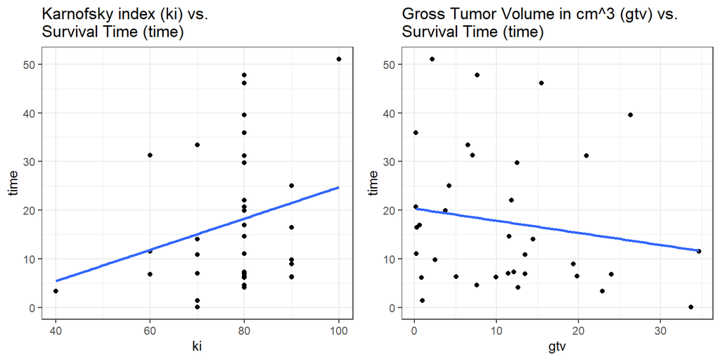

```r
# Scatter plot of survival time over ki values
ki_plot <- ggplot(df_imputed[df_imputed$status == 1,], aes(x = ki, y = time)) +
  geom_point() +
  theme_bw() +
  labs(
    title = "Karnofsky index (ki) vs.\nSurvival Time (time)"
  ) +
  geom_smooth(method = 'lm', se = FALSE)


# Scatter plot of survival time over gtv values
gtv_plot <- ggplot(df_imputed[df_imputed$status == 1,], aes(x = gtv, y = time)) +
  geom_point() +
  theme_bw() +
  labs(
    title = "Gross Tumor Volume in cm^3 (gtv) vs.\nSurvival Time (time)"
  ) +
  geom_smooth(method = 'lm', se = FALSE)

gridExtra::grid.arrange(grobs = list(ki_plot, gtv_plot), nrow = 1, ncol = 2)
```

The above charts suggest that survival time tended to be *longer* for those with higher Karnofsky index scores and tended to be *shorter* for those with larger gross tumor volumes.

### Model building

We now build a [Cox proportional-hazards regression model](https://sphweb.bumc.bu.edu/otlt/MPH-Modules/BS/BS704_Survival/BS704_Survival6.html) to model death risk over time as a function of our explanatory variables. This allows us to obtain hazard ratios that suggest the strength and direction of association that each variable had with risk of death at any given time point during the observation period.

We also divide the sample randomly using an approximate 80%/20% split. 80% are used to build the model, and the remaining 20% are used to assess the fit of the model. This step is important as it provides evidence for the model’s validity and generalizability.

```r
set.seed(1) # The sample function is (pseudo-)random, so we set a random seed for reproducibility.
test_obs <- sample(nrow(df_imputed), round((nrow(df_imputed) * 20) / 100))
train <- df_imputed[-test_obs,]
test <- df_imputed[test_obs,]
```

We use the `survival` package to build the Cox model. We also create a tidy table of the model results using the `broom`, `kable`, and `kableExtra` packages.

```r
# Fit Cox model
model <- survival::coxph(survival::Surv(time, status) ~ ., data = train)

# Examine model summary
summary1 <- summary(model)

# Produce a tidy table of the model results using the broom package
table <- broom::tidy(model, conf.int = TRUE, exponentiate = TRUE)[c("term", "estimate", "conf.low", "conf.high", "p.value")] %>%
            mutate_if(is.numeric, function(x) format(round(x, 2), nsmall = 2))

# Beautify the table of model results
knitr::kable(table, col.names = c("Indicator", "HR", "HR (Low)", "HR (High)", "p-value")) %>%
  kableExtra::kable_styling(bootstrap_options = c("striped", "hover", "condensed")) %>%
  kableExtra::row_spec(row = c(3, 6), bold = TRUE)
```

| Indicator | HR | HR (Low) | HR (High) | p-value |
| --- | --- | --- | --- | --- |
| sexMale | 1.10 | 0.50 | 2.41 | 0.82 |
| diagnosisLG glioma | 2.60 | 0.72 | 9.35 | 0.14 |
| diagnosisHG glioma | 8.13 | 3.15 | 20.98 | 0.00 |
| diagnosisOther | 2.55 | 0.45 | 14.43 | 0.29 |
| locSupratentorial | 1.47 | 0.29 | 7.49 | 0.64 |
| ki | 0.95 | 0.91 | 0.98 | 0.01 |
| gtv | 1.03 | 0.98 | 1.08 | 0.28 |
| stereoSRT | 0.87 | 0.26 | 2.92 | 0.82 |

The model results show that, all other variables in the model held equal:

- Having a **high-grade glioma** diagnosis was associated with about **8 times greater risk of death** in comparison with a diagnosis a meningioma.
- Each one-unit score increase on the **Karnofsky index** was associated with a **5% reduction in the risk of death**.

*Note: risk of death refers to the risk of death at any given time point during the study period. Cox models assume that the relative differences in risk between groups remain constant throughout the entire time period of the study.*

### Model evaluation

Next, we assess the fit of the model via [Harell’s concordance index](https://cran.r-project.org/web/packages/survival/vignettes/concordance.pdf).

```r
# Calculate concordance of the Cox model on the training data
survival::concordance(model)
```

```
## Call:
## concordance.coxph(object = model)
##
## n= 70
## Concordance= 0.7909 se= 0.04256
## concordant discordant     tied.x     tied.y    tied.xy
##       1006        266          0          0          0
```

```r
# Calculate concordance of the Cox model on the test data to assess model fit and generalizability
survival::concordance(model, newdata = test)
```

```
## Call:
## concordance.coxph(object = model, newdata = test)
##
## n= 18
## Concordance= 0.806 se= 0.1224
## concordant discordant     tied.x     tied.y    tied.xy
##         54         13          0          0          0
```

While the model performs relatively well on the training data used to build the model ([concordance](https://www.sciencedirect.com/science/article/pii/S1532046420301246) of about 79%), the more important measure in terms of generalizability is its performance on the testing data. Evaluating the model with the testing data allows us to estimate how well the model fits new, unseen data.

The testing data concordance is about 81%, which is about the same and slightly better than the training data concordance. The concordance value can be interpreted as such: when provided two random test-set observations, the Cox model can predict with about 81% accuracy which will die first. This suggests the model is well-specified and accurate, at least when applied to individuals similar in characteristics to those in the `BrainCancer` dataset. The similar training and testing concordance provides evidence that the model was not overfit to the training data and that it generalizes to new, unseen data.

### Conclusion

This analysis shed light on factors that may be related to risk of death over time after a brain cancer diagnosis. Specifically, receiving a high-grade (HG) glioma diagnosis was related to increased risk of death over time in comparison with receiving a meningioma diagnosis. In contrast, higher scores on the Karnofsky index were related to lower risk of death over time.

The practical implications of these findings are those with high-grade gliomas may be likely to die sooner than those with other types of brain cancer (particularly meningiomas). As well, among individuals with brain cancer, those with higher Karnofsky index scores may tend to live longer than those with lower Karnofsky index scores.

It is important to note that this analysis cannot say anything with certainty about causal effects due to its observational design and relatively small sample size. The observed associations *could* be indicative of causal effects, but additional studies with experimental or quasi-experimental designs would be needed to establish causal relationships with greater certainty. Additional non-experimental observational studies with larger sample sizes would also aid in evaluating the associations found in this analysis.